# Risk Factor Analysis

## Outcome Variable

**Outcome Variable:** haz

## Predictor Variables

**Intervention Variable:** exclfeed3

**Adjustment Set:**

- arm
- sex
- brthmon
- W_mage
- meducyrs
- feducyrs
- hhwealth_quart
- hfoodsec
- W_mhtcm
- W_mwtkg
- W_mbmi
- vagbrth
- W_gagebrth
- W_birthwt
- W_birthlen
- W_nrooms
- W_nchldlt5
- month
- W_parity
- impfloor
- impsan
- safeh20
- delta_W_mage
- delta_meducyrs
- delta_feducyrs
- delta_hhwealth_quart
- delta_hfoodsec
- delta_W_mhtcm
- delta_W_mwtkg
- delta_W_mbmi
- delta_vagbrth
- delta_W_gagebrth
- delta_W_birthwt
- delta_W_birthlen
- delta_W_nrooms
- delta_W_nchldlt5
- delta_month
- delta_W_parity
- delta_impfloor
- delta_impsan
- delta_safeh20

## Stratifying Variables

The analysis was stratified on these variable(s):

- agecat
- studyid
- country

## Data Summary

| agecat | studyid | country | exclfeed3 | n_cell | n |
| --- | --- | --- | --- | --- | --- |
| Birth | CMC-V-BCS-2002 | INDIA | 1 | 4 | 4 |
| Birth | CMC-V-BCS-2002 | INDIA | 0 | 0 | 4 |
| Birth | EE | PAKISTAN | 1 | 35 | 35 |
| Birth | EE | PAKISTAN | 0 | 0 | 35 |
| Birth | GMS-Nepal | NEPAL | 1 | 380 | 458 |
| Birth | GMS-Nepal | NEPAL | 0 | 78 | 458 |
| Birth | IRC | INDIA | 1 | 0 | 10 |
| Birth | IRC | INDIA | 0 | 10 | 10 |
| Birth | JiVitA-3 | BANGLADESH | 1 | 12014 | 13276 |
| Birth | JiVitA-3 | BANGLADESH | 0 | 1262 | 13276 |
| Birth | JiVitA-4 | BANGLADESH | 1 | 105 | 116 |
| Birth | JiVitA-4 | BANGLADESH | 0 | 11 | 116 |
| Birth | Keneba | GAMBIA | 1 | 1198 | 1356 |
| Birth | Keneba | GAMBIA | 0 | 158 | 1356 |
| Birth | MAL-ED | BANGLADESH | 1 | 138 | 215 |
| Birth | MAL-ED | BANGLADESH | 0 | 77 | 215 |
| Birth | MAL-ED | BRAZIL | 1 | 12 | 57 |
| Birth | MAL-ED | BRAZIL | 0 | 45 | 57 |
| Birth | MAL-ED | INDIA | 1 | 24 | 41 |
| Birth | MAL-ED | INDIA | 0 | 17 | 41 |
| Birth | MAL-ED | NEPAL | 1 | 8 | 26 |
| Birth | MAL-ED | NEPAL | 0 | 18 | 26 |
| Birth | MAL-ED | PERU | 1 | 49 | 223 |
| Birth | MAL-ED | PERU | 0 | 174 | 223 |
| Birth | MAL-ED | SOUTH AFRICA | 1 | 12 | 100 |
| Birth | MAL-ED | SOUTH AFRICA | 0 | 88 | 100 |
| Birth | MAL-ED | TANZANIA, UNITED REPUBLIC OF | 1 | 17 | 102 |
| Birth | MAL-ED | TANZANIA, UNITED REPUBLIC OF | 0 | 85 | 102 |
| Birth | PROVIDE | BANGLADESH | 1 | 387 | 539 |
| Birth | PROVIDE | BANGLADESH | 0 | 152 | 539 |

[output cut: 64 more lines]

The following strata were considered:

- agecat: 24 months, studyid: CMC-V-BCS-2002, country: INDIA
- agecat: 24 months, studyid: EE, country: PAKISTAN
- agecat: 24 months, studyid: GMS-Nepal, country: NEPAL
- agecat: 24 months, studyid: IRC, country: INDIA
- agecat: 24 months, studyid: JiVitA-3, country: BANGLADESH
- agecat: 24 months, studyid: JiVitA-4, country: BANGLADESH
- agecat: 24 months, studyid: Keneba, country: GAMBIA
- agecat: 24 months, studyid: MAL-ED, country: BANGLADESH
- agecat: 24 months, studyid: MAL-ED, country: BRAZIL
- agecat: 24 months, studyid: MAL-ED, country: INDIA
- agecat: 24 months, studyid: MAL-ED, country: NEPAL
- agecat: 24 months, studyid: MAL-ED, country: PERU
- agecat: 24 months, studyid: MAL-ED, country: SOUTH AFRICA
- agecat: 24 months, studyid: MAL-ED, country: TANZANIA, UNITED REPUBLIC OF
- agecat: 24 months, studyid: PROVIDE, country: BANGLADESH
- agecat: 6 months, studyid: CMC-V-BCS-2002, country: INDIA
- agecat: 6 months, studyid: EE, country: PAKISTAN
- agecat: 6 months, studyid: GMS-Nepal, country: NEPAL
- agecat: 6 months, studyid: IRC, country: INDIA
- agecat: 6 months, studyid: JiVitA-3, country: BANGLADESH
- agecat: 6 months, studyid: JiVitA-4, country: BANGLADESH
- agecat: 6 months, studyid: Keneba, country: GAMBIA
- agecat: 6 months, studyid: MAL-ED, country: BANGLADESH
- agecat: 6 months, studyid: MAL-ED, country: BRAZIL
- agecat: 6 months, studyid: MAL-ED, country: INDIA
- agecat: 6 months, studyid: MAL-ED, country: NEPAL
- agecat: 6 months, studyid: MAL-ED, country: PERU
- agecat: 6 months, studyid: MAL-ED, country: SOUTH AFRICA
- agecat: 6 months, studyid: MAL-ED, country: TANZANIA, UNITED REPUBLIC OF
- agecat: 6 months, studyid: PROVIDE, country: BANGLADESH
- agecat: 6 months, studyid: SAS-CompFeed, country: INDIA
- agecat: Birth, studyid: CMC-V-BCS-2002, country: INDIA
- agecat: Birth, studyid: EE, country: PAKISTAN
- agecat: Birth, studyid: GMS-Nepal, country: NEPAL
- agecat: Birth, studyid: IRC, country: INDIA
- agecat: Birth, studyid: JiVitA-3, country: BANGLADESH
- agecat: Birth, studyid: JiVitA-4, country: BANGLADESH
- agecat: Birth, studyid: Keneba, country: GAMBIA
- agecat: Birth, studyid: MAL-ED, country: BANGLADESH
- agecat: Birth, studyid: MAL-ED, country: BRAZIL
- agecat: Birth, studyid: MAL-ED, country: INDIA
- agecat: Birth, studyid: MAL-ED, country: NEPAL
- agecat: Birth, studyid: MAL-ED, country: PERU
- agecat: Birth, studyid: MAL-ED, country: SOUTH AFRICA
- agecat: Birth, studyid: MAL-ED, country: TANZANIA, UNITED REPUBLIC OF
- agecat: Birth, studyid: PROVIDE, country: BANGLADESH
- agecat: Birth, studyid: SAS-CompFeed, country: INDIA

### Dropped Strata

- agecat: Birth, studyid: CMC-V-BCS-2002, country: INDIA
- agecat: Birth, studyid: EE, country: PAKISTAN
- agecat: Birth, studyid: IRC, country: INDIA
- agecat: 6 months, studyid: CMC-V-BCS-2002, country: INDIA
- agecat: 6 months, studyid: EE, country: PAKISTAN
- agecat: 6 months, studyid: IRC, country: INDIA
- agecat: 24 months, studyid: CMC-V-BCS-2002, country: INDIA
- agecat: 24 months, studyid: EE, country: PAKISTAN
- agecat: 24 months, studyid: IRC, country: INDIA

## Methods Detail

We’re interested in the causal parameters $E[Y_a]$ for all values of $a \in \mathcal{A}$. These parameters represent the mean outcome if, possibly contrary to fact, we intervened to set all units to have $A=a$. Under the randomization and positivity assumptions, these are identified by the statistical parameters $\psi_a=E_W[E_{Y|A,W}(Y|A=a,W)]$. In addition, we’re interested in the mean of $Y$, $E[Y]$ under no intervention (the observed mean). We will estimate these parameters by using SuperLearner to fit the relevant likelihood factors – $E_{Y|A,W}(Y|A=a,W)$ and $p(A=a|W)$, and then updating our likelihood fit using a joint TMLE.

For unadjusted analyses ($W=\{\}$), initial likelihoods were estimated using Lrnr_glm to estimate the simple $E(Y|A)$ and Lrnr_mean to estimate $p(A)$. For adjusted analyses, a small library containing Lrnr_glmnet, Lrnr_xgboost, and Lrnr_mean was used.

Having estimated these parameters, we will then use the delta method to estimate relative risks and attributable risks relative to a prespecified baseline level of $A$.

# Results Detail

## Results Plots

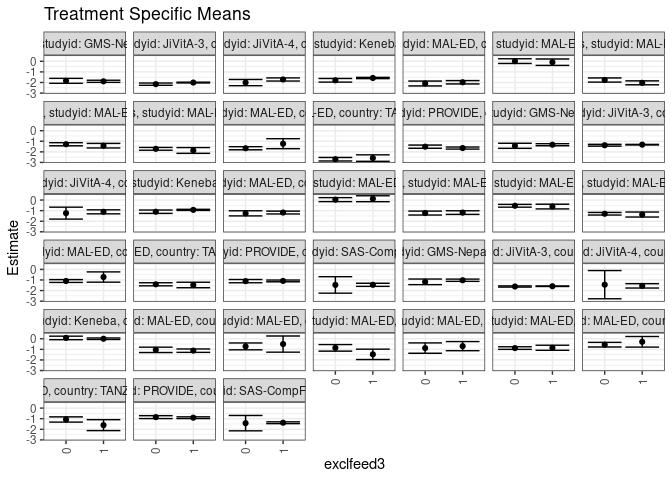

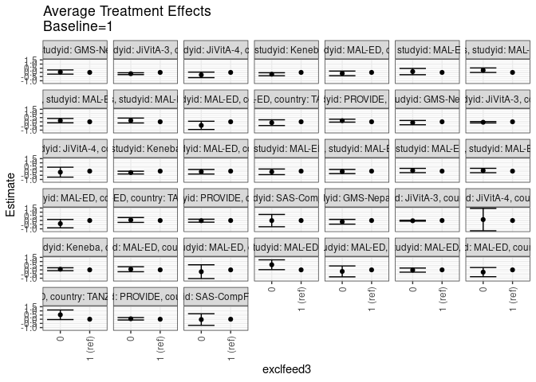

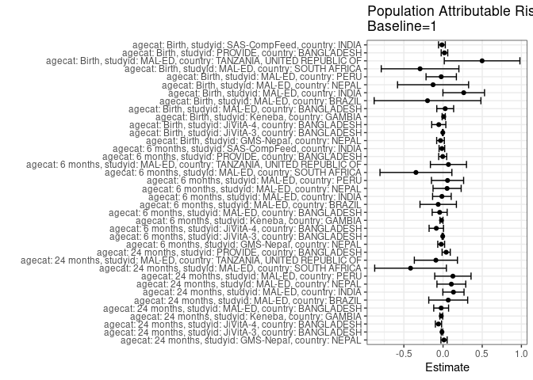

## Results Table

### Parameter: TSM

| agecat | studyid | country | intervention_level | baseline_level | estimate | ci_lower | ci_upper |
| --- | --- | --- | --- | --- | --- | --- | --- |
| Birth | GMS-Nepal | NEPAL | 1 | NA | -1.0231943 | -1.1301915 | -0.9161971 |
| Birth | GMS-Nepal | NEPAL | 0 | NA | -1.1733290 | -1.4375510 | -0.9091069 |
| Birth | JiVitA-3 | BANGLADESH | 1 | NA | -1.5898494 | -1.6134685 | -1.5662303 |
| Birth | JiVitA-3 | BANGLADESH | 0 | NA | -1.6154830 | -1.6702938 | -1.5606722 |
| Birth | JiVitA-4 | BANGLADESH | 1 | NA | -1.5527682 | -1.7583542 | -1.3471823 |
| Birth | JiVitA-4 | BANGLADESH | 0 | NA | -1.4409494 | -2.7737118 | -0.1081869 |
| Birth | Keneba | GAMBIA | 1 | NA | 0.0013583 | -0.0718009 | 0.0745175 |
| Birth | Keneba | GAMBIA | 0 | NA | 0.0779466 | -0.0891943 | 0.2450875 |
| Birth | MAL-ED | BANGLADESH | 1 | NA | -1.1226789 | -1.2831219 | -0.9622358 |
| Birth | MAL-ED | BANGLADESH | 0 | NA | -1.0466337 | -1.2995687 | -0.7936987 |
| Birth | MAL-ED | BRAZIL | 1 | NA | -0.5017155 | -1.2638539 | 0.2604229 |
| Birth | MAL-ED | BRAZIL | 0 | NA | -0.7213633 | -1.0436809 | -0.3990456 |
| Birth | MAL-ED | INDIA | 1 | NA | -1.4714430 | -1.9606224 | -0.9822636 |
| Birth | MAL-ED | INDIA | 0 | NA | -0.8576786 | -1.1688021 | -0.5465551 |
| Birth | MAL-ED | NEPAL | 1 | NA | -0.6962500 | -1.1273498 | -0.2651502 |
| Birth | MAL-ED | NEPAL | 0 | NA | -0.8800000 | -1.3706027 | -0.3893973 |
| Birth | MAL-ED | PERU | 1 | NA | -0.8520626 | -1.0912038 | -0.6129215 |
| Birth | MAL-ED | PERU | 0 | NA | -0.8791446 | -1.0035503 | -0.7547389 |
| Birth | MAL-ED | SOUTH AFRICA | 1 | NA | -0.2864578 | -0.7863513 | 0.2134357 |
| Birth | MAL-ED | SOUTH AFRICA | 0 | NA | -0.5588398 | -0.7781569 | -0.3395227 |
| Birth | MAL-ED | TANZANIA, UNITED REPUBLIC OF | 1 | NA | -1.6070827 | -2.1233397 | -1.0908257 |
| Birth | MAL-ED | TANZANIA, UNITED REPUBLIC OF | 0 | NA | -1.0722901 | -1.3185182 | -0.8260619 |
| Birth | PROVIDE | BANGLADESH | 1 | NA | -0.9031761 | -0.9845857 | -0.8217666 |
| Birth | PROVIDE | BANGLADESH | 0 | NA | -0.8488725 | -0.9850439 | -0.7127011 |
| Birth | SAS-CompFeed | INDIA | 1 | NA | -1.3791852 | -1.4632653 | -1.2951052 |
| Birth | SAS-CompFeed | INDIA | 0 | NA | -1.4188476 | -2.1434587 | -0.6942365 |
| 6 months | GMS-Nepal | NEPAL | 1 | NA | -1.3263283 | -1.4213460 | -1.2313106 |
| 6 months | GMS-Nepal | NEPAL | 0 | NA | -1.4269688 | -1.6663482 | -1.1875893 |
| 6 months | JiVitA-3 | BANGLADESH | 1 | NA | -1.3197186 | -1.3488830 | -1.2905543 |
| 6 months | JiVitA-3 | BANGLADESH | 0 | NA | -1.3746230 | -1.4595696 | -1.2896764 |
| 6 months | JiVitA-4 | BANGLADESH | 1 | NA | -1.1134409 | -1.3032710 | -0.9236109 |
| 6 months | JiVitA-4 | BANGLADESH | 0 | NA | -1.2361332 | -1.7995432 | -0.6727233 |
| 6 months | Keneba | GAMBIA | 1 | NA | -0.9288188 | -0.9828669 | -0.8747707 |
| 6 months | Keneba | GAMBIA | 0 | NA | -1.1032379 | -1.2613745 | -0.9451013 |
| 6 months | MAL-ED | BANGLADESH | 1 | NA | -1.1813799 | -1.3152657 | -1.0474941 |
| 6 months | MAL-ED | BANGLADESH | 0 | NA | -1.2552341 | -1.4961389 | -1.0143293 |
| 6 months | MAL-ED | BRAZIL | 1 | NA | 0.1227280 | -0.1582946 | 0.4037505 |
| 6 months | MAL-ED | BRAZIL | 0 | NA | 0.0389752 | -0.1495291 | 0.2274794 |
| 6 months | MAL-ED | INDIA | 1 | NA | -1.1857187 | -1.3568709 | -1.0145665 |
| 6 months | MAL-ED | INDIA | 0 | NA | -1.2291299 | -1.4156677 | -1.0425922 |
| 6 months | MAL-ED | NEPAL | 1 | NA | -0.6151873 | -0.8383579 | -0.3920167 |
| 6 months | MAL-ED | NEPAL | 0 | NA | -0.5404773 | -0.6716034 | -0.4093513 |
| 6 months | MAL-ED | PERU | 1 | NA | -1.3683176 | -1.6036639 | -1.1329713 |
| 6 months | MAL-ED | PERU | 0 | NA | -1.2934206 | -1.4141927 | -1.1726485 |
| 6 months | MAL-ED | SOUTH AFRICA | 1 | NA | -0.7203679 | -1.2037050 | -0.2370308 |
| 6 months | MAL-ED | SOUTH AFRICA | 0 | NA | -1.0972736 | -1.2324146 | -0.9621326 |
| 6 months | MAL-ED | TANZANIA, UNITED REPUBLIC OF | 1 | NA | -1.4718741 | -1.7303781 | -1.2133700 |
| 6 months | MAL-ED | TANZANIA, UNITED REPUBLIC OF | 0 | NA | -1.4066019 | -1.5500268 | -1.2631770 |
| 6 months | PROVIDE | BANGLADESH | 1 | NA | -1.0873626 | -1.1712441 | -1.0034811 |
| 6 months | PROVIDE | BANGLADESH | 0 | NA | -1.1091830 | -1.2638617 | -0.9545043 |
| 6 months | SAS-CompFeed | INDIA | 1 | NA | -1.4549959 | -1.6008850 | -1.3091069 |
| 6 months | SAS-CompFeed | INDIA | 0 | NA | -1.4654856 | -2.2428805 | -0.6880907 |
| 24 months | GMS-Nepal | NEPAL | 1 | NA | -1.8880129 | -1.9894666 | -1.7865593 |
| 24 months | GMS-Nepal | NEPAL | 0 | NA | -1.8442330 | -2.0766959 | -1.6117701 |
| 24 months | JiVitA-3 | BANGLADESH | 1 | NA | -2.0051368 | -2.0429150 | -1.9673585 |
| 24 months | JiVitA-3 | BANGLADESH | 0 | NA | -2.1568974 | -2.2644379 | -2.0493570 |
| 24 months | JiVitA-4 | BANGLADESH | 1 | NA | -1.7143651 | -1.8622618 | -1.5664683 |
| 24 months | JiVitA-4 | BANGLADESH | 0 | NA | -2.0080362 | -2.3025635 | -1.7135089 |
| 24 months | Keneba | GAMBIA | 1 | NA | -1.5737219 | -1.6306825 | -1.5167612 |
| 24 months | Keneba | GAMBIA | 0 | NA | -1.7917329 | -1.9638374 | -1.6196283 |
| 24 months | MAL-ED | BANGLADESH | 1 | NA | -1.9776874 | -2.1348815 | -1.8204933 |
| 24 months | MAL-ED | BANGLADESH | 0 | NA | -2.0946731 | -2.3242222 | -1.8651241 |
| 24 months | MAL-ED | BRAZIL | 1 | NA | -0.0823438 | -0.3845866 | 0.2198990 |
| 24 months | MAL-ED | BRAZIL | 0 | NA | 0.0181696 | -0.2036868 | 0.2400259 |
| 24 months | MAL-ED | INDIA | 1 | NA | -2.0320523 | -2.2175043 | -1.8466003 |
| 24 months | MAL-ED | INDIA | 0 | NA | -1.7650013 | -1.9605880 | -1.5694147 |
| 24 months | MAL-ED | NEPAL | 1 | NA | -1.4169636 | -1.6330755 | -1.2008517 |
| 24 months | MAL-ED | NEPAL | 0 | NA | -1.2808489 | -1.4272687 | -1.1344291 |
| 24 months | MAL-ED | PERU | 1 | NA | -1.8669773 | -2.1387164 | -1.5952382 |
| 24 months | MAL-ED | PERU | 0 | NA | -1.7155289 | -1.8476471 | -1.5834106 |
| 24 months | MAL-ED | SOUTH AFRICA | 1 | NA | -1.2277879 | -1.6977505 | -0.7578253 |
| 24 months | MAL-ED | SOUTH AFRICA | 0 | NA | -1.6585990 | -1.8044303 | -1.5127677 |
| 24 months | MAL-ED | TANZANIA, UNITED REPUBLIC OF | 1 | NA | -2.5855990 | -2.8898646 | -2.2813334 |
| 24 months | MAL-ED | TANZANIA, UNITED REPUBLIC OF | 0 | NA | -2.6937377 | -2.8582262 | -2.5292492 |
| 24 months | PROVIDE | BANGLADESH | 1 | NA | -1.6423537 | -1.7396953 | -1.5450120 |
| 24 months | PROVIDE | BANGLADESH | 0 | NA | -1.5092923 | -1.6598640 | -1.3587205 |

### Parameter: E(Y)

| agecat | studyid | country | intervention_level | baseline_level | estimate | ci_lower | ci_upper |
| --- | --- | --- | --- | --- | --- | --- | --- |
| Birth | GMS-Nepal | NEPAL | NA | NA | -1.0555240 | -1.1550843 | -0.9559638 |
| Birth | JiVitA-3 | BANGLADESH | NA | NA | -1.5928457 | -1.6158667 | -1.5698248 |
| Birth | JiVitA-4 | BANGLADESH | NA | NA | -1.6073276 | -1.8105798 | -1.4040753 |
| Birth | Keneba | GAMBIA | NA | NA | 0.0098304 | -0.0597854 | 0.0794461 |
| Birth | MAL-ED | BANGLADESH | NA | NA | -1.0949767 | -1.2319917 | -0.9579618 |
| Birth | MAL-ED | BRAZIL | NA | NA | -0.6996491 | -0.9856018 | -0.4136965 |
| Birth | MAL-ED | INDIA | NA | NA | -1.2075610 | -1.5261540 | -0.8889679 |
| Birth | MAL-ED | NEPAL | NA | NA | -0.8234615 | -1.1896049 | -0.4573182 |
| Birth | MAL-ED | PERU | NA | NA | -0.8753812 | -0.9932108 | -0.7575515 |
| Birth | MAL-ED | SOUTH AFRICA | NA | NA | -0.5797000 | -0.7788298 | -0.3805702 |
| Birth | MAL-ED | TANZANIA, UNITED REPUBLIC OF | NA | NA | -1.1086275 | -1.3310338 | -0.8862211 |
| Birth | PROVIDE | BANGLADESH | NA | NA | -0.8851020 | -0.9601332 | -0.8100709 |
| Birth | SAS-CompFeed | INDIA | NA | NA | -1.3937088 | -1.5095039 | -1.2779137 |
| 6 months | GMS-Nepal | NEPAL | NA | NA | -1.3499849 | -1.4387386 | -1.2612312 |
| 6 months | JiVitA-3 | BANGLADESH | NA | NA | -1.3240051 | -1.3526414 | -1.2953689 |
| 6 months | JiVitA-4 | BANGLADESH | NA | NA | -1.1994318 | -1.3808291 | -1.0180345 |
| 6 months | Keneba | GAMBIA | NA | NA | -0.9489317 | -1.0001696 | -0.8976937 |
| 6 months | MAL-ED | BANGLADESH | NA | NA | -1.2242918 | -1.3439424 | -1.1046413 |
| 6 months | MAL-ED | BRAZIL | NA | NA | 0.0609091 | -0.0944768 | 0.2162950 |
| 6 months | MAL-ED | INDIA | NA | NA | -1.2002381 | -1.3274929 | -1.0729833 |
| 6 months | MAL-ED | NEPAL | NA | NA | -0.5634068 | -0.6769687 | -0.4498449 |
| 6 months | MAL-ED | PERU | NA | NA | -1.3108735 | -1.4182407 | -1.2035062 |
| 6 months | MAL-ED | SOUTH AFRICA | NA | NA | -1.0662227 | -1.1965862 | -0.9358591 |
| 6 months | MAL-ED | TANZANIA, UNITED REPUBLIC OF | NA | NA | -1.4030503 | -1.5292443 | -1.2768563 |
| 6 months | PROVIDE | BANGLADESH | NA | NA | -1.0916915 | -1.1661176 | -1.0172654 |
| 6 months | SAS-CompFeed | INDIA | NA | NA | -1.4697236 | -1.6333919 | -1.3060553 |
| 24 months | GMS-Nepal | NEPAL | NA | NA | -1.8752995 | -1.9688053 | -1.7817937 |
| 24 months | JiVitA-3 | BANGLADESH | NA | NA | -2.0187325 | -2.0554682 | -1.9819968 |
| 24 months | JiVitA-4 | BANGLADESH | NA | NA | -1.7726490 | -1.9111913 | -1.6341067 |
| 24 months | Keneba | GAMBIA | NA | NA | -1.5961170 | -1.6505261 | -1.5417080 |
| 24 months | MAL-ED | BANGLADESH | NA | NA | -2.0016585 | -2.1303297 | -1.8729874 |
| 24 months | MAL-ED | BRAZIL | NA | NA | -0.0162939 | -0.1929098 | 0.1603221 |
| 24 months | MAL-ED | INDIA | NA | NA | -1.8994059 | -2.0346781 | -1.7641337 |
| 24 months | MAL-ED | NEPAL | NA | NA | -1.3109318 | -1.4313748 | -1.1904888 |
| 24 months | MAL-ED | PERU | NA | NA | -1.7412963 | -1.8630698 | -1.6195228 |
| 24 months | MAL-ED | SOUTH AFRICA | NA | NA | -1.6424525 | -1.7808926 | -1.5040124 |
| 24 months | MAL-ED | TANZANIA, UNITED REPUBLIC OF | NA | NA | -2.6768207 | -2.8213178 | -2.5323235 |
| 24 months | PROVIDE | BANGLADESH | NA | NA | -1.6024221 | -1.6857420 | -1.5191023 |

### Parameter: ATE

| agecat | studyid | country | intervention_level | baseline_level | estimate | ci_lower | ci_upper |
| --- | --- | --- | --- | --- | --- | --- | --- |
| Birth | GMS-Nepal | NEPAL | 1 | 1 | 0.0000000 | 0.0000000 | 0.0000000 |
| Birth | GMS-Nepal | NEPAL | 0 | 1 | -0.1501347 | -0.4351747 | 0.1349053 |
| Birth | JiVitA-3 | BANGLADESH | 1 | 1 | 0.0000000 | 0.0000000 | 0.0000000 |
| Birth | JiVitA-3 | BANGLADESH | 0 | 1 | -0.0256336 | -0.0805693 | 0.0293020 |
| Birth | JiVitA-4 | BANGLADESH | 1 | 1 | 0.0000000 | 0.0000000 | 0.0000000 |
| Birth | JiVitA-4 | BANGLADESH | 0 | 1 | 0.1118189 | -1.2348728 | 1.4585106 |
| Birth | Keneba | GAMBIA | 1 | 1 | 0.0000000 | 0.0000000 | 0.0000000 |
| Birth | Keneba | GAMBIA | 0 | 1 | 0.0765883 | -0.0979323 | 0.2511089 |
| Birth | MAL-ED | BANGLADESH | 1 | 1 | 0.0000000 | 0.0000000 | 0.0000000 |
| Birth | MAL-ED | BANGLADESH | 0 | 1 | 0.0760452 | -0.2236657 | 0.3757560 |
| Birth | MAL-ED | BRAZIL | 1 | 1 | 0.0000000 | 0.0000000 | 0.0000000 |
| Birth | MAL-ED | BRAZIL | 0 | 1 | -0.2196478 | -1.0461423 | 0.6068468 |
| Birth | MAL-ED | INDIA | 1 | 1 | 0.0000000 | 0.0000000 | 0.0000000 |
| Birth | MAL-ED | INDIA | 0 | 1 | 0.6137644 | 0.0266458 | 1.2008830 |
| Birth | MAL-ED | NEPAL | 1 | 1 | 0.0000000 | 0.0000000 | 0.0000000 |
| Birth | MAL-ED | NEPAL | 0 | 1 | -0.1837500 | -0.8368488 | 0.4693488 |
| Birth | MAL-ED | PERU | 1 | 1 | 0.0000000 | 0.0000000 | 0.0000000 |
| Birth | MAL-ED | PERU | 0 | 1 | -0.0270820 | -0.2737221 | 0.2195582 |
| Birth | MAL-ED | SOUTH AFRICA | 1 | 1 | 0.0000000 | 0.0000000 | 0.0000000 |
| Birth | MAL-ED | SOUTH AFRICA | 0 | 1 | -0.2723820 | -0.8232167 | 0.2784527 |
| Birth | MAL-ED | TANZANIA, UNITED REPUBLIC OF | 1 | 1 | 0.0000000 | 0.0000000 | 0.0000000 |
| Birth | MAL-ED | TANZANIA, UNITED REPUBLIC OF | 0 | 1 | 0.5347927 | -0.0391185 | 1.1087038 |
| Birth | PROVIDE | BANGLADESH | 1 | 1 | 0.0000000 | 0.0000000 | 0.0000000 |
| Birth | PROVIDE | BANGLADESH | 0 | 1 | 0.0543037 | -0.0909013 | 0.1995087 |
| Birth | SAS-CompFeed | INDIA | 1 | 1 | 0.0000000 | 0.0000000 | 0.0000000 |
| Birth | SAS-CompFeed | INDIA | 0 | 1 | -0.0396624 | -0.7382457 | 0.6589209 |
| 6 months | GMS-Nepal | NEPAL | 1 | 1 | 0.0000000 | 0.0000000 | 0.0000000 |
| 6 months | GMS-Nepal | NEPAL | 0 | 1 | -0.1006405 | -0.3584304 | 0.1571495 |
| 6 months | JiVitA-3 | BANGLADESH | 1 | 1 | 0.0000000 | 0.0000000 | 0.0000000 |
| 6 months | JiVitA-3 | BANGLADESH | 0 | 1 | -0.0549044 | -0.1406515 | 0.0308428 |
| 6 months | JiVitA-4 | BANGLADESH | 1 | 1 | 0.0000000 | 0.0000000 | 0.0000000 |
| 6 months | JiVitA-4 | BANGLADESH | 0 | 1 | -0.1226923 | -0.7166194 | 0.4712348 |
| 6 months | Keneba | GAMBIA | 1 | 1 | 0.0000000 | 0.0000000 | 0.0000000 |
| 6 months | Keneba | GAMBIA | 0 | 1 | -0.1744191 | -0.3413403 | -0.0074978 |
| 6 months | MAL-ED | BANGLADESH | 1 | 1 | 0.0000000 | 0.0000000 | 0.0000000 |
| 6 months | MAL-ED | BANGLADESH | 0 | 1 | -0.0738542 | -0.3501431 | 0.2024347 |
| 6 months | MAL-ED | BRAZIL | 1 | 1 | 0.0000000 | 0.0000000 | 0.0000000 |
| 6 months | MAL-ED | BRAZIL | 0 | 1 | -0.0837528 | -0.4205674 | 0.2530618 |
| 6 months | MAL-ED | INDIA | 1 | 1 | 0.0000000 | 0.0000000 | 0.0000000 |
| 6 months | MAL-ED | INDIA | 0 | 1 | -0.0434112 | -0.2949501 | 0.2081277 |
| 6 months | MAL-ED | NEPAL | 1 | 1 | 0.0000000 | 0.0000000 | 0.0000000 |
| 6 months | MAL-ED | NEPAL | 0 | 1 | 0.0747099 | -0.1846125 | 0.3340324 |
| 6 months | MAL-ED | PERU | 1 | 1 | 0.0000000 | 0.0000000 | 0.0000000 |
| 6 months | MAL-ED | PERU | 0 | 1 | 0.0748970 | -0.1897214 | 0.3395154 |
| 6 months | MAL-ED | SOUTH AFRICA | 1 | 1 | 0.0000000 | 0.0000000 | 0.0000000 |
| 6 months | MAL-ED | SOUTH AFRICA | 0 | 1 | -0.3769057 | -0.8799242 | 0.1261127 |
| 6 months | MAL-ED | TANZANIA, UNITED REPUBLIC OF | 1 | 1 | 0.0000000 | 0.0000000 | 0.0000000 |
| 6 months | MAL-ED | TANZANIA, UNITED REPUBLIC OF | 0 | 1 | 0.0652722 | -0.2257313 | 0.3562756 |
| 6 months | PROVIDE | BANGLADESH | 1 | 1 | 0.0000000 | 0.0000000 | 0.0000000 |
| 6 months | PROVIDE | BANGLADESH | 0 | 1 | -0.0218204 | -0.1978910 | 0.1542501 |
| 6 months | SAS-CompFeed | INDIA | 1 | 1 | 0.0000000 | 0.0000000 | 0.0000000 |
| 6 months | SAS-CompFeed | INDIA | 0 | 1 | -0.0104897 | -0.7471588 | 0.7261794 |
| 24 months | GMS-Nepal | NEPAL | 1 | 1 | 0.0000000 | 0.0000000 | 0.0000000 |
| 24 months | GMS-Nepal | NEPAL | 0 | 1 | 0.0437799 | -0.2068344 | 0.2943943 |
| 24 months | JiVitA-3 | BANGLADESH | 1 | 1 | 0.0000000 | 0.0000000 | 0.0000000 |
| 24 months | JiVitA-3 | BANGLADESH | 0 | 1 | -0.1517607 | -0.2621269 | -0.0413945 |
| 24 months | JiVitA-4 | BANGLADESH | 1 | 1 | 0.0000000 | 0.0000000 | 0.0000000 |
| 24 months | JiVitA-4 | BANGLADESH | 0 | 1 | -0.2936711 | -0.6249348 | 0.0375925 |
| 24 months | Keneba | GAMBIA | 1 | 1 | 0.0000000 | 0.0000000 | 0.0000000 |
| 24 months | Keneba | GAMBIA | 0 | 1 | -0.2180110 | -0.3981054 | -0.0379166 |
| 24 months | MAL-ED | BANGLADESH | 1 | 1 | 0.0000000 | 0.0000000 | 0.0000000 |
| 24 months | MAL-ED | BANGLADESH | 0 | 1 | -0.1169858 | -0.3952129 | 0.1612413 |
| 24 months | MAL-ED | BRAZIL | 1 | 1 | 0.0000000 | 0.0000000 | 0.0000000 |
| 24 months | MAL-ED | BRAZIL | 0 | 1 | 0.1005134 | -0.2750110 | 0.4760378 |
| 24 months | MAL-ED | INDIA | 1 | 1 | 0.0000000 | 0.0000000 | 0.0000000 |
| 24 months | MAL-ED | INDIA | 0 | 1 | 0.2670510 | -0.0024176 | 0.5365196 |
| 24 months | MAL-ED | NEPAL | 1 | 1 | 0.0000000 | 0.0000000 | 0.0000000 |
| 24 months | MAL-ED | NEPAL | 0 | 1 | 0.1361147 | -0.1257457 | 0.3979751 |
| 24 months | MAL-ED | PERU | 1 | 1 | 0.0000000 | 0.0000000 | 0.0000000 |
| 24 months | MAL-ED | PERU | 0 | 1 | 0.1514484 | -0.1422627 | 0.4451596 |
| 24 months | MAL-ED | SOUTH AFRICA | 1 | 1 | 0.0000000 | 0.0000000 | 0.0000000 |
| 24 months | MAL-ED | SOUTH AFRICA | 0 | 1 | -0.4308111 | -0.9247990 | 0.0631767 |
| 24 months | MAL-ED | TANZANIA, UNITED REPUBLIC OF | 1 | 1 | 0.0000000 | 0.0000000 | 0.0000000 |
| 24 months | MAL-ED | TANZANIA, UNITED REPUBLIC OF | 0 | 1 | -0.1081387 | -0.4546620 | 0.2383846 |
| 24 months | PROVIDE | BANGLADESH | 1 | 1 | 0.0000000 | 0.0000000 | 0.0000000 |
| 24 months | PROVIDE | BANGLADESH | 0 | 1 | 0.1330614 | -0.0430539 | 0.3091768 |

### Parameter: PAR

| agecat | studyid | country | intervention_level | baseline_level | estimate | ci_lower | ci_upper |
| --- | --- | --- | --- | --- | --- | --- | --- |
| Birth | GMS-Nepal | NEPAL | 1 | NA | -0.0323297 | -0.0812788 | 0.0166193 |
| Birth | JiVitA-3 | BANGLADESH | 1 | NA | -0.0029964 | -0.0082345 | 0.0022418 |
| Birth | JiVitA-4 | BANGLADESH | 1 | NA | -0.0545594 | -0.1447128 | 0.0355940 |
| Birth | Keneba | GAMBIA | 1 | NA | 0.0084721 | -0.0118935 | 0.0288377 |
| Birth | MAL-ED | BANGLADESH | 1 | NA | 0.0277021 | -0.0798049 | 0.1352092 |
| Birth | MAL-ED | BRAZIL | 1 | NA | -0.1979336 | -0.8791223 | 0.4832551 |
| Birth | MAL-ED | INDIA | 1 | NA | 0.2638820 | -0.0016697 | 0.5294337 |
| Birth | MAL-ED | NEPAL | 1 | NA | -0.1272115 | -0.5805774 | 0.3261543 |
| Birth | MAL-ED | PERU | 1 | NA | -0.0233185 | -0.2168956 | 0.1702585 |
| Birth | MAL-ED | SOUTH AFRICA | 1 | NA | -0.2932422 | -0.7885888 | 0.2021043 |
| Birth | MAL-ED | TANZANIA, UNITED REPUBLIC OF | 1 | NA | 0.4984553 | 0.0159090 | 0.9810016 |
| Birth | PROVIDE | BANGLADESH | 1 | NA | 0.0180741 | -0.0238274 | 0.0599756 |
| Birth | SAS-CompFeed | INDIA | 1 | NA | -0.0145236 | -0.0577567 | 0.0287095 |
| 6 months | GMS-Nepal | NEPAL | 1 | NA | -0.0236566 | -0.0674200 | 0.0201068 |
| 6 months | JiVitA-3 | BANGLADESH | 1 | NA | -0.0042865 | -0.0117591 | 0.0031861 |
| 6 months | JiVitA-4 | BANGLADESH | 1 | NA | -0.0859909 | -0.1779307 | 0.0059490 |
| 6 months | Keneba | GAMBIA | 1 | NA | -0.0201128 | -0.0393999 | -0.0008257 |
| 6 months | MAL-ED | BANGLADESH | 1 | NA | -0.0429119 | -0.1387001 | 0.0528762 |
| 6 months | MAL-ED | BRAZIL | 1 | NA | -0.0618189 | -0.2940944 | 0.1704566 |
| 6 months | MAL-ED | INDIA | 1 | NA | -0.0145194 | -0.1331920 | 0.1041532 |
| 6 months | MAL-ED | NEPAL | 1 | NA | 0.0517805 | -0.1275808 | 0.2311418 |
| 6 months | MAL-ED | PERU | 1 | NA | 0.0574442 | -0.1478033 | 0.2626916 |
| 6 months | MAL-ED | SOUTH AFRICA | 1 | NA | -0.3458548 | -0.8045965 | 0.1128870 |
| 6 months | MAL-ED | TANZANIA, UNITED REPUBLIC OF | 1 | NA | 0.0688238 | -0.1614112 | 0.2990587 |
| 6 months | PROVIDE | BANGLADESH | 1 | NA | -0.0043289 | -0.0555115 | 0.0468537 |
| 6 months | SAS-CompFeed | INDIA | 1 | NA | -0.0147277 | -0.0507565 | 0.0213012 |
| 24 months | GMS-Nepal | NEPAL | 1 | NA | 0.0127135 | -0.0268763 | 0.0523032 |
| 24 months | JiVitA-3 | BANGLADESH | 1 | NA | -0.0135957 | -0.0230963 | -0.0040951 |
| 24 months | JiVitA-4 | BANGLADESH | 1 | NA | -0.0582840 | -0.0979514 | -0.0186165 |
| 24 months | Keneba | GAMBIA | 1 | NA | -0.0223951 | -0.0407152 | -0.0040751 |
| 24 months | MAL-ED | BANGLADESH | 1 | NA | -0.0239712 | -0.1187224 | 0.0707800 |
| 24 months | MAL-ED | BRAZIL | 1 | NA | 0.0660500 | -0.1822439 | 0.3143438 |
| 24 months | MAL-ED | INDIA | 1 | NA | 0.1326464 | -0.0025216 | 0.2678144 |
| 24 months | MAL-ED | NEPAL | 1 | NA | 0.1060318 | -0.0777941 | 0.2898577 |
| 24 months | MAL-ED | PERU | 1 | NA | 0.1256810 | -0.1060132 | 0.3573752 |
| 24 months | MAL-ED | SOUTH AFRICA | 1 | NA | -0.4146646 | -0.8721869 | 0.0428577 |
| 24 months | MAL-ED | TANZANIA, UNITED REPUBLIC OF | 1 | NA | -0.0912217 | -0.3662667 | 0.1838234 |
| 24 months | PROVIDE | BANGLADESH | 1 | NA | 0.0399315 | -0.0122118 | 0.0920749 |